# Домашние задания по математической статистике

### Гаварина Светлана, СКБ-171

# Домашнее задание 4.

# Проверка статистических гипотез

#### Пусть в распределении Пуассона $\lambda = 3$, в распределении Рэлея $ \sigma = 3 $. Сгенерируем выборки:

#### 1) Распределение Пуассона

```python
import random
import numpy as np
import math

# Функция вероятности (закон распределения) Пуассона
def f_Pois(x, lamb):
    return math.exp(-lamb) * lamb ** x / math.factorial(x)

#Функция распределения
def F_Pois(x, lamb):
    s = 0
    for i in range(x - 1):
        s += math.exp(-lamb) * lamb ** i / math.factorial(i)
    return s

# функция генерации выборки
def rand_Pois(lamb, n):
    nums = []
    for i in range(n):
        p = math.exp(-lamb)
        sp = 0
        sp += p
        u = random.uniform(0,1)
        j = 0
        while u > sp:
            j += 1         # p_j
            p *= lamb / j  # p_j / p_j-1 = lamb / j
            sp += p
        nums.append(j)
    return nums
```

```python
lamb = 3

pois10 = []
pois100 = []
pois1500 = []
pois5000 = []
pois105 = []
# Все выборки сразу сделаем вариационными рядами для удобства дальнейших вычислений
for i in range(5):
    pois10.append(sorted(rand_Pois(lamb, 10)))
    pois100.append(sorted(rand_Pois(lamb, 100)))
    pois1500.append(sorted(rand_Pois(lamb, 1500)))
    pois5000.append(sorted(rand_Pois(lamb, 5000)))
    pois105.append(sorted(rand_Pois(lamb, 10**5)))
```

#### 2) Распределение Рэлея

```python
# Закон распределения Рэлея
def F_Rayl(x, sigma):
    return 1 - math.exp(-(x ** 2) / (2 * sigma ** 2))

def inv_f_Rayl(sigma, u):
    return sigma * math.sqrt(-2 * math.log(u))

# Функция генерации выборки
def rand_Rayl(sigma, n):
    nums = []
    for i in range(n):
        u = random.uniform(0, 1)
        nums.append(inv_f_Rayl(sigma, u))
    return nums
```

```python
sigma = 3

rayl10 = []
rayl100 = []
rayl1500 = []
rayl5000 = []
rayl105 = []
# Все выборки сразу сделаем вариационными рядами для удобства дальнейших вычислений
for i in range(5):
    rayl10.append(sorted(rand_Rayl(lamb, 10)))
    rayl100.append(sorted(rand_Rayl(lamb, 100)))
    rayl1500.append(sorted(rand_Rayl(lamb, 1500)))
    rayl5000.append(sorted(rand_Rayl(lamb, 5000)))
    rayl105.append(sorted(rand_Rayl(lamb, 10**5)))
```

```python
import matplotlib.pyplot as plt
from bisect import bisect_right

def emp(distr):
    '''Эмпирическая функция, возвращает функцию, возвращающую набор y'''
    n = len(distr)
    yy = []
    count = 0
    for i, val in enumerate(distr):
        if not count:
            prev = val
        if prev == val:
            count += 1
        else:
            yy += count * [i / n]
            prev = val
            count = 1
    yy += count * [i / n]
    def emp_yy(x, distr=distr, yy=yy):
        if x < distr[0]:
            return 0.
        return yy[bisect_right(distr, x) - 1]
    return emp_yy
```

```python
def show_emp(distrs, is_discr):
    '''Рисует графики эмпирических функций для 5 распределений'''
    fig, ax = plt.subplots(1, 5, figsize=(25, 4))
    for i, v in enumerate(distrs):
        emp_d = emp(v)
        if is_discr:
            xx = range(max(v) + 1)
            yy = [emp_d(x) for x in xx]
            ax[i].bar(xx, yy, alpha = 0.5, color = 'DarkCyan', align = 'center', width=1)
        else:
            xx = np.arange(0, max(v) + 1, 0.1)
            yy = [emp_d(x) for x in xx]
            ax[i].plot(xx, yy, color = 'DarkCyan')
        ax[i].set_title('Выборка объемом %r'%len(v))
```

## 1. Проверка гипотез о виде распределения

### 1.1. Критерий хи-квадрат К. Пирсона

Критерий хи-квадрат считается одним из самых универсальных методов проверки статистических гипотез. В качестве **меры отклонения** эмпирических данных от гипотетических берется величина $\chi^2 = \sum\limits_{i=1}^N \dfrac{(v_i - np_i)^2}{np_i},\;\; v=(v_1\dots v_N) $ -- вектор частот, полученный из выборки, $p=(p_1 \dots p_N)$ -- заданный вероятностный вектор, рассчитанный по предполагаемому распределению, наблюдаемая величина $\xi$ принимает значения от 1 до $N$ (для дискретных величин). Выборка разбивается на N интервалов.

Данная статистика при $n\rightarrow \infty$ имеет $\chi^2$-распределение с $k=N-r-1$ (для сложных гипотез) или $k=N-1$ (для простых), где $r$ -- число параметров распределения, $N$ -- число интервалов (после объединения, см. далее). Это накладывает ограничение на объем выборки при использовании данного критерия: при разбиении ее на интервалы в каждом должно быть не менее 5 величин, в противном случае интервалы объединяются. Однако для выборок очень малых объемов (например, 10) это бессмысленно: в каждом интервале соль мало величин, что для достижения пяти штук в каждом придется объединять их в 1-2 интервала. Следовательно, k будет принимать в том числе отрицательные значения, что невозможно.

> Число интервалов будем искать по формуле Старджесса: $N = \log_2{n} + 1$ для непрерывного распределения. Для дискретного примем N за максимальный элемент выборки.

Для выбранного уровня значимости по таблице распределения $\chi^2$ находится критическое значение $\chi^2_{\alpha; k}$. Если $\chi^2 > \chi^2_{\alpha;k}$, то принятая гипотеза $H_0$ отвергается, в противном случае принимается.

> **Достоинство** данного критерия в том, что он универсален и подходит для исследования как дискретных, так и непрерывных величин. **Недостаток** же заключается в зависимости от объема выборки, так как статистика имеет $\chi^2$-распределение только при $n\rightarrow \infty$.

```python
import math

def p_v(distr, is_discr, par):
    '''
    Функция ищет вектора v=(v1...vN) эмп.частот и p=(p1...pN) теоретич. частот для распределений Пуассона и Рэлея
    '''
    p = list()
    v = list()
    n = len(distr)
    if is_discr:
        N = max(distr)
        for i in range(N + 1):
            v.append(distr.count(i))
            p.append(f_Pois(i, par))
    else:
        N = int(math.log(n, 2) + 1)
        end = math.ceil(max(distr))
#         print('Увелич. max:', end)
        step0 = math.floor(end / N)
        step = step0 if step0 != 0 else 1
#         print('Шаг:', step)
        prev_i = 0
        ind = 0
        for i in range(step, end, step):
            count = 0
            while (ind < n) and (distr[ind] <= i):
                count += 1
                ind += 1
            v.append(count)
            p.append(F_Rayl(i, par) - F_Rayl(prev_i, par))
            prev_i = i
    return p, v

def chi2(distr, is_discr, par):
    '''Функция вычисляет значение хи-квадрат, возвращает кол-во интервалов (нужно д/поиска квантилей)'''
    chi = list()
    n = len(distr)
    p, v = p_v(distr, is_discr, par)
#     p, v = correct_p_v(p, v)
    for i in range(0, len(v)):
        chi.append((v[i] - n * p[i]) ** 2 / (n * p[i]))
    return len(p), sum(chi)
```

```python
import pandas as pd
hi2_set = pd.read_csv('hi-2.csv', sep=';', dtype='float')

def print_chi2(distr, is_discr, par, alpha, is_simple):
    n = len(distr)
    N, chi = chi2(distr, is_discr, par)
    k = N - 1 if is_simple else N - 1 - 1
    chik = hi2_set[str(alpha)][k-1]
    print(f'hi^2 = {np.round(chi, 3):6}, hi^2_k = {np.round(chik, 3):6}', end=' ')
    print(f'=> Т.к. hi^2 {"≤" if chi <= chik else ">"} hi^2k, гипотеза H0 {"не" if chi > chik else "  "} принимается')
```

#### 1.1.1 Распределение Пуассона

Возьмем по одной выборке каждого объема и построим график эмпирической функции распределения:

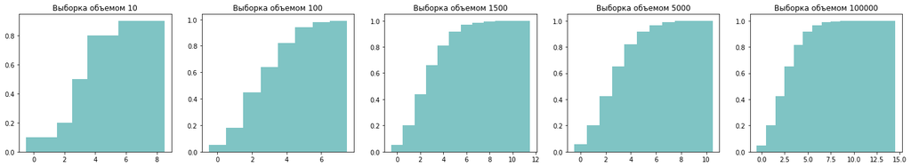

```python
distrs_pois0= [pois10[0], pois100[0], pois1500[0], pois5000[0], pois105[0]]
show_emp(distrs_pois0, True)
```

По виду графиков можно предположить, что данные распределены по закону Пуассона с параметром $\lambda=3$.

Таким образом, гипотеза $H_0$: случайная величина Х распределена по закону Пуассона.

Применим критерий хи-квадрат для уровней значимости $\alpha=0.100$, $\alpha=0.050$

```python
alphas = [0.1, 0.05]
distrs_pois = [pois10, pois100, pois1500, pois5000, pois105]

for distrs in distrs_pois:
    print(f'\n========================== Для выборок объемом {len(distrs[0]):6} =========================')
    for alpha in alphas:
        print(f'------------------------------- Для alpha = {alpha:4} ------------------------------')
        for distr in distrs:
            print_chi2(distr, True, 3, alpha, True)
```

```
========================== Для выборок объемом     10 =========================
------------------------------- Для alpha =  0.1 ------------------------------
hi^2 = 16.117, hi^2_k = 13.362 => Т.к. hi^2 > hi^2k, гипотеза H0 не принимается
hi^2 =  2.576, hi^2_k =  9.236 => Т.к. hi^2 ≤ hi^2k, гипотеза H0    принимается
hi^2 =  5.262, hi^2_k = 10.645 => Т.к. hi^2 ≤ hi^2k, гипотеза H0    принимается
hi^2 =  4.577, hi^2_k = 12.017 => Т.к. hi^2 ≤ hi^2k, гипотеза H0    принимается
hi^2 =  2.733, hi^2_k = 10.645 => Т.к. hi^2 ≤ hi^2k, гипотеза H0    принимается
------------------------------- Для alpha = 0.05 ------------------------------
hi^2 = 16.117, hi^2_k = 15.507 => Т.к. hi^2 > hi^2k, гипотеза H0 не принимается
hi^2 =  2.576, hi^2_k =  11.07 => Т.к. hi^2 ≤ hi^2k, гипотеза H0    принимается
hi^2 =  5.262, hi^2_k = 12.592 => Т.к. hi^2 ≤ hi^2k, гипотеза H0    принимается
hi^2 =  4.577, hi^2_k = 14.067 => Т.к. hi^2 ≤ hi^2k, гипотеза H0    принимается
hi^2 =  2.733, hi^2_k = 12.592 => Т.к. hi^2 ≤ hi^2k, гипотеза H0    принимается

========================== Для выборок объемом    100 =========================
------------------------------- Для alpha =  0.1 ------------------------------
hi^2 =  2.388, hi^2_k = 12.017 => Т.к. hi^2 ≤ hi^2k, гипотеза H0    принимается
hi^2 = 14.675, hi^2_k = 15.987 => Т.к. hi^2 ≤ hi^2k, гипотеза H0    принимается
hi^2 = 11.887, hi^2_k = 13.362 => Т.к. hi^2 ≤ hi^2k, гипотеза H0    принимается
hi^2 = 17.207, hi^2_k = 12.017 => Т.к. hi^2 > hi^2k, гипотеза H0 не принимается
hi^2 = 10.802, hi^2_k = 14.684 => Т.к. hi^2 ≤ hi^2k, гипотеза H0    принимается
------------------------------- Для alpha = 0.05 ------------------------------
hi^2 =  2.388, hi^2_k = 14.067 => Т.к. hi^2 ≤ hi^2k, гипотеза H0    принимается
hi^2 = 14.675, hi^2_k = 18.307 => Т.к. hi^2 ≤ hi^2k, гипотеза H0    принимается
hi^2 = 11.887, hi^2_k = 15.507 => Т.к. hi^2 ≤ hi^2k, гипотеза H0    принимается
hi^2 = 17.207, hi^2_k = 14.067 => Т.к. hi^2 > hi^2k, гипотеза H0 не принимается
hi^2 = 10.802, hi^2_k = 16.919 => Т.к. hi^2 ≤ hi^2k, гипотеза H0    принимается

========================== Для выборок объемом   1500 =========================
------------------------------- Для alpha =  0.1 ------------------------------
hi^2 =  10.21, hi^2_k = 17.275 => Т.к. hi^2 ≤ hi^2k, гипотеза H0    принимается
hi^2 =  9.146, hi^2_k = 15.987 => Т.к. hi^2 ≤ hi^2k, гипотеза H0    принимается
hi^2 = 13.476, hi^2_k = 17.275 => Т.к. hi^2 ≤ hi^2k, гипотеза H0    принимается
hi^2 =  5.275, hi^2_k = 15.987 => Т.к. hi^2 ≤ hi^2k, гипотеза H0    принимается
hi^2 =  3.483, hi^2_k = 13.362 => Т.к. hi^2 ≤ hi^2k, гипотеза H0    принимается
------------------------------- Для alpha = 0.05 ------------------------------
hi^2 =  10.21, hi^2_k = 19.675 => Т.к. hi^2 ≤ hi^2k, гипотеза H0    принимается
hi^2 =  9.146, hi^2_k = 18.307 => Т.к. hi^2 ≤ hi^2k, гипотеза H0    принимается
hi^2 = 13.476, hi^2_k = 19.675 => Т.к. hi^2 ≤ hi^2k, гипотеза H0    принимается
hi^2 =  5.275, hi^2_k = 18.307 => Т.к. hi^2 ≤ hi^2k, гипотеза H0    принимается
```

[output cut: 14 more lines]

```
hi^2 = 17.114, hi^2_k = 19.675 => Т.к. hi^2 ≤ hi^2k, гипотеза H0    принимается

========================== Для выборок объемом 100000 =========================
------------------------------- Для alpha =  0.1 ------------------------------
hi^2 = 11.078, hi^2_k = 21.064 => Т.к. hi^2 ≤ hi^2k, гипотеза H0    принимается
hi^2 =  8.387, hi^2_k = 19.812 => Т.к. hi^2 ≤ hi^2k, гипотеза H0    принимается
hi^2 =  12.92, hi^2_k = 19.812 => Т.к. hi^2 ≤ hi^2k, гипотеза H0    принимается
hi^2 =  9.002, hi^2_k = 19.812 => Т.к. hi^2 ≤ hi^2k, гипотеза H0    принимается
hi^2 = 13.186, hi^2_k = 19.812 => Т.к. hi^2 ≤ hi^2k, гипотеза H0    принимается
------------------------------- Для alpha = 0.05 ------------------------------
hi^2 = 11.078, hi^2_k = 23.685 => Т.к. hi^2 ≤ hi^2k, гипотеза H0    принимается
hi^2 =  8.387, hi^2_k = 22.362 => Т.к. hi^2 ≤ hi^2k, гипотеза H0    принимается
hi^2 =  12.92, hi^2_k = 22.362 => Т.к. hi^2 ≤ hi^2k, гипотеза H0    принимается
hi^2 =  9.002, hi^2_k = 22.362 => Т.к. hi^2 ≤ hi^2k, гипотеза H0    принимается
hi^2 = 13.186, hi^2_k = 22.362 => Т.к. hi^2 ≤ hi^2k, гипотеза H0    принимается
```

**Сложная гипотеза**

Гипотеза $H_0$ выглядит так:

- Данные распределены по закону Пуассона с параметром, равным оценке максимального правдоподобия для этой выборки.

В предыдущей домашней работе мы получили оценку методом максимального правдоподобия для параметра $\widehat{\lambda} = \overline{X}$. Вычислим его для всех выборок и применим критерий хи-квадрат для получившихся оценок параметров:

```python
import numpy as np

for distrs in distrs_pois:
    print(f'\n========================== Для выборок объемом {len(distrs[0]):6} =========================')
    for alpha in alphas:
        print(f'------------------------------- Для alpha = {alpha:4} ------------------------------')
        for distr in distrs:
            print_chi2(distr, True, np.mean(distr), alpha, False)
```

```
========================== Для выборок объемом     10 =========================
------------------------------- Для alpha =  0.1 ------------------------------
hi^2 =   9.25, hi^2_k = 12.017 => Т.к. hi^2 ≤ hi^2k, гипотеза H0    принимается
hi^2 =  2.514, hi^2_k =  7.779 => Т.к. hi^2 ≤ hi^2k, гипотеза H0    принимается
hi^2 =  6.163, hi^2_k =  9.236 => Т.к. hi^2 ≤ hi^2k, гипотеза H0    принимается
hi^2 =  5.014, hi^2_k = 10.645 => Т.к. hi^2 ≤ hi^2k, гипотеза H0    принимается
hi^2 =  3.136, hi^2_k =  9.236 => Т.к. hi^2 ≤ hi^2k, гипотеза H0    принимается
------------------------------- Для alpha = 0.05 ------------------------------
hi^2 =   9.25, hi^2_k = 14.067 => Т.к. hi^2 ≤ hi^2k, гипотеза H0    принимается
hi^2 =  2.514, hi^2_k =  9.488 => Т.к. hi^2 ≤ hi^2k, гипотеза H0    принимается
hi^2 =  6.163, hi^2_k =  11.07 => Т.к. hi^2 ≤ hi^2k, гипотеза H0    принимается
hi^2 =  5.014, hi^2_k = 12.592 => Т.к. hi^2 ≤ hi^2k, гипотеза H0    принимается
hi^2 =  3.136, hi^2_k =  11.07 => Т.к. hi^2 ≤ hi^2k, гипотеза H0    принимается

========================== Для выборок объемом    100 =========================
------------------------------- Для alpha =  0.1 ------------------------------
hi^2 =  2.518, hi^2_k = 10.645 => Т.к. hi^2 ≤ hi^2k, гипотеза H0    принимается
hi^2 = 11.458, hi^2_k = 14.684 => Т.к. hi^2 ≤ hi^2k, гипотеза H0    принимается
hi^2 = 11.479, hi^2_k = 12.017 => Т.к. hi^2 ≤ hi^2k, гипотеза H0    принимается
hi^2 =  17.91, hi^2_k = 10.645 => Т.к. hi^2 > hi^2k, гипотеза H0 не принимается
hi^2 = 10.952, hi^2_k = 13.362 => Т.к. hi^2 ≤ hi^2k, гипотеза H0    принимается
------------------------------- Для alpha = 0.05 ------------------------------
hi^2 =  2.518, hi^2_k = 12.592 => Т.к. hi^2 ≤ hi^2k, гипотеза H0    принимается
hi^2 = 11.458, hi^2_k = 16.919 => Т.к. hi^2 ≤ hi^2k, гипотеза H0    принимается
hi^2 = 11.479, hi^2_k = 14.067 => Т.к. hi^2 ≤ hi^2k, гипотеза H0    принимается
hi^2 =  17.91, hi^2_k = 12.592 => Т.к. hi^2 > hi^2k, гипотеза H0 не принимается
hi^2 = 10.952, hi^2_k = 15.507 => Т.к. hi^2 ≤ hi^2k, гипотеза H0    принимается

========================== Для выборок объемом   1500 =========================
------------------------------- Для alpha =  0.1 ------------------------------
hi^2 = 10.299, hi^2_k = 15.987 => Т.к. hi^2 ≤ hi^2k, гипотеза H0    принимается
hi^2 =  9.138, hi^2_k = 14.684 => Т.к. hi^2 ≤ hi^2k, гипотеза H0    принимается
hi^2 = 13.676, hi^2_k = 15.987 => Т.к. hi^2 ≤ hi^2k, гипотеза H0    принимается
hi^2 =  5.135, hi^2_k = 14.684 => Т.к. hi^2 ≤ hi^2k, гипотеза H0    принимается
hi^2 =   2.54, hi^2_k = 12.017 => Т.к. hi^2 ≤ hi^2k, гипотеза H0    принимается
------------------------------- Для alpha = 0.05 ------------------------------
hi^2 = 10.299, hi^2_k = 18.307 => Т.к. hi^2 ≤ hi^2k, гипотеза H0    принимается
hi^2 =  9.138, hi^2_k = 16.919 => Т.к. hi^2 ≤ hi^2k, гипотеза H0    принимается
hi^2 = 13.676, hi^2_k = 18.307 => Т.к. hi^2 ≤ hi^2k, гипотеза H0    принимается
hi^2 =  5.135, hi^2_k = 16.919 => Т.к. hi^2 ≤ hi^2k, гипотеза H0    принимается
```

[output cut: 14 more lines]

```
hi^2 = 16.515, hi^2_k = 18.307 => Т.к. hi^2 ≤ hi^2k, гипотеза H0    принимается

========================== Для выборок объемом 100000 =========================
------------------------------- Для alpha =  0.1 ------------------------------
hi^2 =  9.149, hi^2_k = 19.812 => Т.к. hi^2 ≤ hi^2k, гипотеза H0    принимается
hi^2 =  8.335, hi^2_k = 18.549 => Т.к. hi^2 ≤ hi^2k, гипотеза H0    принимается
hi^2 =  12.73, hi^2_k = 18.549 => Т.к. hi^2 ≤ hi^2k, гипотеза H0    принимается
hi^2 =  6.749, hi^2_k = 18.549 => Т.к. hi^2 ≤ hi^2k, гипотеза H0    принимается
hi^2 = 13.071, hi^2_k = 18.549 => Т.к. hi^2 ≤ hi^2k, гипотеза H0    принимается
------------------------------- Для alpha = 0.05 ------------------------------
hi^2 =  9.149, hi^2_k = 22.362 => Т.к. hi^2 ≤ hi^2k, гипотеза H0    принимается
hi^2 =  8.335, hi^2_k = 21.026 => Т.к. hi^2 ≤ hi^2k, гипотеза H0    принимается
hi^2 =  12.73, hi^2_k = 21.026 => Т.к. hi^2 ≤ hi^2k, гипотеза H0    принимается
hi^2 =  6.749, hi^2_k = 21.026 => Т.к. hi^2 ≤ hi^2k, гипотеза H0    принимается
hi^2 = 13.071, hi^2_k = 21.026 => Т.к. hi^2 ≤ hi^2k, гипотеза H0    принимается
```

Изменив проверяемый параметр на заведомо неверный (например, 3.1), можно заметить, что на выборках небольших объемов критерий дает противоречивые результаты, однако на больших выборках гипотеза однозначно отвергается:

```python
for distr in distrs_pois0:
    print(f'n = {len(distr):6}. ', end='')
    print_chi2(distr, True, 3.1, 0.1, False)
```

```
n =     10. hi^2 = 14.145, hi^2_k = 12.017 => Т.к. hi^2 > hi^2k, гипотеза H0 не принимается
n =    100. hi^2 =  2.644, hi^2_k = 10.645 => Т.к. hi^2 ≤ hi^2k, гипотеза H0    принимается
n =   1500. hi^2 = 16.226, hi^2_k = 15.987 => Т.к. hi^2 > hi^2k, гипотеза H0 не принимается
n =   5000. hi^2 = 26.726, hi^2_k = 14.684 => Т.к. hi^2 > hi^2k, гипотеза H0 не принимается
n = 100000. hi^2 = 382.916, hi^2_k = 19.812 => Т.к. hi^2 > hi^2k, гипотеза H0 не принимается
```

#### 1.1.2 Распределение Рэлея

Возьмем выборки объемами 10, 100, 1500, 5000, 10^5 и построим графики Э.Ф.Р. для одной выборки каждого размера:

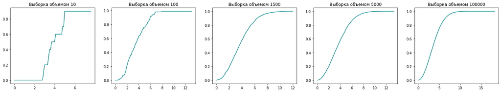

```python
distrs_rayl0 = [rayl10[0], rayl100[0], rayl1500[0], rayl5000[0], rayl105[0]]

show_emp(distrs_rayl0, False)
```

По виду графиков можно предположить, что данные распределены по закону Рэлея с параметром $\lambda\approx3$.

Таким образом, гипотеза $H_0$: случайная величина Х распределена по закону Рэлея.

Применим критерий хи-квадрат для уровней значимости $\alpha=0.100$, $\alpha=0.050$

```python
alphas = [0.100, 0.050]
distrs_rayl = [rayl10, rayl100, rayl1500, rayl5000, rayl105]

for distrs in distrs_rayl:
    print(f'\n========================== Для выборок объемом {len(distrs[0]):6} =========================')
    for alpha in alphas:
        print(f'------------------------------- Для alpha = {alpha:4} ------------------------------')
        for distr in distrs:
            print_chi2(distr, False, 3, alpha)
```

```
========================== Для выборок объемом     10 =========================
------------------------------- Для alpha =  0.1 ------------------------------
hi^2 =  4.746, hi^2_k =  6.251 => Т.к. hi^2 ≤ hi^2k, гипотеза H0    принимается
hi^2 =  3.177, hi^2_k =  6.251 => Т.к. hi^2 ≤ hi^2k, гипотеза H0    принимается
hi^2 =  1.175, hi^2_k =  6.251 => Т.к. hi^2 ≤ hi^2k, гипотеза H0    принимается
hi^2 =  3.293, hi^2_k =  6.251 => Т.к. hi^2 ≤ hi^2k, гипотеза H0    принимается
hi^2 =  3.324, hi^2_k =  4.605 => Т.к. hi^2 ≤ hi^2k, гипотеза H0    принимается
------------------------------- Для alpha = 0.05 ------------------------------
hi^2 =  4.746, hi^2_k =  7.815 => Т.к. hi^2 ≤ hi^2k, гипотеза H0    принимается
hi^2 =  3.177, hi^2_k =  7.815 => Т.к. hi^2 ≤ hi^2k, гипотеза H0    принимается
hi^2 =  1.175, hi^2_k =  7.815 => Т.к. hi^2 ≤ hi^2k, гипотеза H0    принимается
hi^2 =  3.293, hi^2_k =  7.815 => Т.к. hi^2 ≤ hi^2k, гипотеза H0    принимается
hi^2 =  3.324, hi^2_k =  5.991 => Т.к. hi^2 ≤ hi^2k, гипотеза H0    принимается

========================== Для выборок объемом    100 =========================
------------------------------- Для alpha =  0.1 ------------------------------
hi^2 =  3.811, hi^2_k = 12.017 => Т.к. hi^2 ≤ hi^2k, гипотеза H0    принимается
hi^2 =  5.709, hi^2_k = 13.362 => Т.к. hi^2 ≤ hi^2k, гипотеза H0    принимается
hi^2 = 10.857, hi^2_k = 12.017 => Т.к. hi^2 ≤ hi^2k, гипотеза H0    принимается
hi^2 =  4.148, hi^2_k = 12.017 => Т.к. hi^2 ≤ hi^2k, гипотеза H0    принимается
hi^2 =  6.163, hi^2_k = 12.017 => Т.к. hi^2 ≤ hi^2k, гипотеза H0    принимается
------------------------------- Для alpha = 0.05 ------------------------------
hi^2 =  3.811, hi^2_k = 14.067 => Т.к. hi^2 ≤ hi^2k, гипотеза H0    принимается
hi^2 =  5.709, hi^2_k = 15.507 => Т.к. hi^2 ≤ hi^2k, гипотеза H0    принимается
hi^2 = 10.857, hi^2_k = 14.067 => Т.к. hi^2 ≤ hi^2k, гипотеза H0    принимается
hi^2 =  4.148, hi^2_k = 14.067 => Т.к. hi^2 ≤ hi^2k, гипотеза H0    принимается
hi^2 =  6.163, hi^2_k = 14.067 => Т.к. hi^2 ≤ hi^2k, гипотеза H0    принимается

========================== Для выборок объемом   1500 =========================
------------------------------- Для alpha =  0.1 ------------------------------
hi^2 = 12.141, hi^2_k = 15.987 => Т.к. hi^2 ≤ hi^2k, гипотеза H0    принимается
hi^2 = 20.258, hi^2_k = 14.684 => Т.к. hi^2 > hi^2k, гипотеза H0 не принимается
hi^2 =  3.478, hi^2_k = 14.684 => Т.к. hi^2 ≤ hi^2k, гипотеза H0    принимается
hi^2 =  9.228, hi^2_k = 13.362 => Т.к. hi^2 ≤ hi^2k, гипотеза H0    принимается
hi^2 = 11.265, hi^2_k = 14.684 => Т.к. hi^2 ≤ hi^2k, гипотеза H0    принимается
------------------------------- Для alpha = 0.05 ------------------------------
hi^2 = 12.141, hi^2_k = 18.307 => Т.к. hi^2 ≤ hi^2k, гипотеза H0    принимается
hi^2 = 20.258, hi^2_k = 16.919 => Т.к. hi^2 > hi^2k, гипотеза H0 не принимается
hi^2 =  3.478, hi^2_k = 16.919 => Т.к. hi^2 ≤ hi^2k, гипотеза H0    принимается
hi^2 =  9.228, hi^2_k = 15.507 => Т.к. hi^2 ≤ hi^2k, гипотеза H0    принимается
```

[output cut: 14 more lines]

```
hi^2 =  5.792, hi^2_k = 18.307 => Т.к. hi^2 ≤ hi^2k, гипотеза H0    принимается

========================== Для выборок объемом 100000 =========================
------------------------------- Для alpha =  0.1 ------------------------------
hi^2 = 18.766, hi^2_k = 18.549 => Т.к. hi^2 > hi^2k, гипотеза H0 не принимается
hi^2 =  9.807, hi^2_k = 18.549 => Т.к. hi^2 ≤ hi^2k, гипотеза H0    принимается
hi^2 =  11.98, hi^2_k = 19.812 => Т.к. hi^2 ≤ hi^2k, гипотеза H0    принимается
hi^2 =  7.755, hi^2_k = 18.549 => Т.к. hi^2 ≤ hi^2k, гипотеза H0    принимается
hi^2 = 16.616, hi^2_k = 18.549 => Т.к. hi^2 ≤ hi^2k, гипотеза H0    принимается
------------------------------- Для alpha = 0.05 ------------------------------
hi^2 = 18.766, hi^2_k = 21.026 => Т.к. hi^2 ≤ hi^2k, гипотеза H0    принимается
hi^2 =  9.807, hi^2_k = 21.026 => Т.к. hi^2 ≤ hi^2k, гипотеза H0    принимается
hi^2 =  11.98, hi^2_k = 22.362 => Т.к. hi^2 ≤ hi^2k, гипотеза H0    принимается
hi^2 =  7.755, hi^2_k = 21.026 => Т.к. hi^2 ≤ hi^2k, гипотеза H0    принимается
hi^2 = 16.616, hi^2_k = 21.026 => Т.к. hi^2 ≤ hi^2k, гипотеза H0    принимается
```

**Сложная гипотеза**

Гипотеза $H_0$ выглядит так:

- Данные распределены по закону Рэлея с параметром, равным оценке максимального правдоподобия для этой выборки.

В предыдущей домашней работе мы получили оценку методом максимального правдоподобия для параметра $\sigma$:

$ \widehat{\sigma} = \sqrt{\dfrac{\dfrac{1}{n}\sum\limits_{i=1}x_i^2}{2}}$

Вычислим ее для каждой выборки и применим критерий хи-квадрат для оценок параметра:

```python
def estim_s(distr):
    s2 = sum(map(lambda x: x ** 2, distr))
    return math.sqrt(s2  / (2 * len(distr)))

for distrs in distrs_rayl:
    print(f'\n========================== Для выборок объемом {len(distrs[0]):6} =========================')
    for alpha in alphas:
        print(f'------------------------------- Для alpha = {alpha:4} ------------------------------')
        for distr in distrs:
            print_chi2(distr, False, estim_s(distr), alpha)
```

```
========================== Для выборок объемом     10 =========================
------------------------------- Для alpha =  0.1 ------------------------------
hi^2 =  4.707, hi^2_k =  6.251 => Т.к. hi^2 ≤ hi^2k, гипотеза H0    принимается
hi^2 =  3.146, hi^2_k =  6.251 => Т.к. hi^2 ≤ hi^2k, гипотеза H0    принимается
hi^2 =  2.598, hi^2_k =  6.251 => Т.к. hi^2 ≤ hi^2k, гипотеза H0    принимается
hi^2 =  1.695, hi^2_k =  6.251 => Т.к. hi^2 ≤ hi^2k, гипотеза H0    принимается
hi^2 =    3.0, hi^2_k =  4.605 => Т.к. hi^2 ≤ hi^2k, гипотеза H0    принимается
------------------------------- Для alpha = 0.05 ------------------------------
hi^2 =  4.707, hi^2_k =  7.815 => Т.к. hi^2 ≤ hi^2k, гипотеза H0    принимается
hi^2 =  3.146, hi^2_k =  7.815 => Т.к. hi^2 ≤ hi^2k, гипотеза H0    принимается
hi^2 =  2.598, hi^2_k =  7.815 => Т.к. hi^2 ≤ hi^2k, гипотеза H0    принимается
hi^2 =  1.695, hi^2_k =  7.815 => Т.к. hi^2 ≤ hi^2k, гипотеза H0    принимается
hi^2 =    3.0, hi^2_k =  5.991 => Т.к. hi^2 ≤ hi^2k, гипотеза H0    принимается

========================== Для выборок объемом    100 =========================
------------------------------- Для alpha =  0.1 ------------------------------
hi^2 =    3.7, hi^2_k = 12.017 => Т.к. hi^2 ≤ hi^2k, гипотеза H0    принимается
hi^2 =  1.846, hi^2_k = 13.362 => Т.к. hi^2 ≤ hi^2k, гипотеза H0    принимается
hi^2 = 10.883, hi^2_k = 12.017 => Т.к. hi^2 ≤ hi^2k, гипотеза H0    принимается
hi^2 =  3.277, hi^2_k = 12.017 => Т.к. hi^2 ≤ hi^2k, гипотеза H0    принимается
hi^2 =  6.214, hi^2_k = 12.017 => Т.к. hi^2 ≤ hi^2k, гипотеза H0    принимается
------------------------------- Для alpha = 0.05 ------------------------------
hi^2 =    3.7, hi^2_k = 14.067 => Т.к. hi^2 ≤ hi^2k, гипотеза H0    принимается
hi^2 =  1.846, hi^2_k = 15.507 => Т.к. hi^2 ≤ hi^2k, гипотеза H0    принимается
hi^2 = 10.883, hi^2_k = 14.067 => Т.к. hi^2 ≤ hi^2k, гипотеза H0    принимается
hi^2 =  3.277, hi^2_k = 14.067 => Т.к. hi^2 ≤ hi^2k, гипотеза H0    принимается
hi^2 =  6.214, hi^2_k = 14.067 => Т.к. hi^2 ≤ hi^2k, гипотеза H0    принимается

========================== Для выборок объемом   1500 =========================
------------------------------- Для alpha =  0.1 ------------------------------
hi^2 = 12.245, hi^2_k = 15.987 => Т.к. hi^2 ≤ hi^2k, гипотеза H0    принимается
hi^2 = 19.484, hi^2_k = 14.684 => Т.к. hi^2 > hi^2k, гипотеза H0 не принимается
hi^2 =  3.163, hi^2_k = 14.684 => Т.к. hi^2 ≤ hi^2k, гипотеза H0    принимается
hi^2 =  5.597, hi^2_k = 13.362 => Т.к. hi^2 ≤ hi^2k, гипотеза H0    принимается
hi^2 =   10.7, hi^2_k = 14.684 => Т.к. hi^2 ≤ hi^2k, гипотеза H0    принимается
------------------------------- Для alpha = 0.05 ------------------------------
hi^2 = 12.245, hi^2_k = 18.307 => Т.к. hi^2 ≤ hi^2k, гипотеза H0    принимается
hi^2 = 19.484, hi^2_k = 16.919 => Т.к. hi^2 > hi^2k, гипотеза H0 не принимается
hi^2 =  3.163, hi^2_k = 16.919 => Т.к. hi^2 ≤ hi^2k, гипотеза H0    принимается
hi^2 =  5.597, hi^2_k = 15.507 => Т.к. hi^2 ≤ hi^2k, гипотеза H0    принимается
```

[output cut: 14 more lines]

```
hi^2 =  5.665, hi^2_k = 18.307 => Т.к. hi^2 ≤ hi^2k, гипотеза H0    принимается

========================== Для выборок объемом 100000 =========================
------------------------------- Для alpha =  0.1 ------------------------------
hi^2 =  14.64, hi^2_k = 18.549 => Т.к. hi^2 ≤ hi^2k, гипотеза H0    принимается
hi^2 =  9.202, hi^2_k = 18.549 => Т.к. hi^2 ≤ hi^2k, гипотеза H0    принимается
hi^2 = 11.955, hi^2_k = 19.812 => Т.к. hi^2 ≤ hi^2k, гипотеза H0    принимается
hi^2 =  7.613, hi^2_k = 18.549 => Т.к. hi^2 ≤ hi^2k, гипотеза H0    принимается
hi^2 = 13.335, hi^2_k = 18.549 => Т.к. hi^2 ≤ hi^2k, гипотеза H0    принимается
------------------------------- Для alpha = 0.05 ------------------------------
hi^2 =  14.64, hi^2_k = 21.026 => Т.к. hi^2 ≤ hi^2k, гипотеза H0    принимается
hi^2 =  9.202, hi^2_k = 21.026 => Т.к. hi^2 ≤ hi^2k, гипотеза H0    принимается
hi^2 = 11.955, hi^2_k = 22.362 => Т.к. hi^2 ≤ hi^2k, гипотеза H0    принимается
hi^2 =  7.613, hi^2_k = 21.026 => Т.к. hi^2 ≤ hi^2k, гипотеза H0    принимается
hi^2 = 13.335, hi^2_k = 21.026 => Т.к. hi^2 ≤ hi^2k, гипотеза H0    принимается
```

Итак, построим гипотезы $H_0$. Они будут одинаковы для всех трех выборок:

- Данные распределены по закону Рэлея с параметром 3.

Вычисления будут аналогичны проверкам простых гипотез.

### 1.2 Критерий согласия Колмогорова-Смирнова (для непрерывного распределения)

Данный критерий основан на сравнении Э.Ф.Р. с предполагаемой функцией распределения, а именно: в качестве **меры расхождения** используется максимум абсолютного значения разности Э.Ф.Р. и Т.Ф.Р.

Таким образом, $D_n=max\left|F_n(x)-F(x)\right|$ -- статистика критерия Колмогорова.

При $n\rightarrow\infty$ $P(D_n\sqrt{n} \geqslant \lambda)$ стремится к распределению Колмогорова $ P(\lambda)=1 - \sum\limits_{k=-\infty}^{+\infty}(-1)^ke^{-2k^2\lambda^2}$.

Если $H_0$ -- гипотеза о виде распределения, то, чтобы определиться, принимать ее или нет, необходимо вычислить $\lambda=D_n\sqrt{n}$ и сравнить с $\lambda_\alpha$ (находится по таблице), где $\alpha$ -- уровень значимости. Если $D_n\sqrt{n} \leq \lambda$, то гипотеза принимается.

Вместо $\lambda=D_n \sqrt{n}$ лучше использовать вид статистики с поправкой Большева: $\lambda=S=\dfrac{6nD_n+1}{6\sqrt{n}}$, т.к. к распределению Колмогорова он сходится быстрее.

**Достоинство** данного критерия в том, что он может применяться на выборках в том числе малых объемом. **Недостаток** же -- возможность использования только для непрерывных распределений.

```python
def n_dn (distr, par):
    xx = np.arange(0, max(distr), 0.1)
    empf = emp(distr)
    fn = np.array([empf(x) for x in xx])
    f = np.array([F_Rayl(x, par) for x in xx])
    dn = max(abs(fn-f))
    return dn

l_set = {'0.1': 1.22, '0.05': 1.36}

def print_kstest(distr, par, alpha):
    n = len(distr)
    dn = n_dn(distr, par)
    s = (6 * n * dn + 1) / (6 * math.sqrt(n))
    la = l_set[str(alpha)]
    print(f'Dn = {dn:.3f}, l = S = {s:.3f}, la = {la:.3f}', end=' ')
    print(f'=> Т.к. l {"≤" if s <= la else ">"} la, гипотеза H0 {"не" if s > la else "  "} принимается')
```

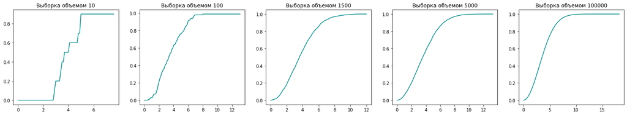

```python
distrs_rayl0 = [rayl10[0], rayl100[0], rayl1500[0], rayl5000[0], rayl105[0]]

show_emp(distrs_rayl0, False)
```

По виду графиков можно предположить, что данные распределены по закону Рэлея с параметром $\lambda\approx3$.

Таким образом, гипотеза $H_0$: случайная величина Х распределена по закону Рэлея с параметром 3.

Применим критерий Колмогорова-Смирнова для уровней значимости $\alpha=0.1$, $\alpha=0.05$:

```python
alphas = ['0.1', '0.05']

for distrs in distrs_rayl:
    print(f'\n========================== Для выборок объемом {len(distrs[0]):6} ==========================')
    for alpha in alphas:
        print(f'------------------------------- Для alpha = {alpha:4} -------------------------------')
        for distr in distrs:
            print_kstest(distr, 3, alpha)
```

```
========================== Для выборок объемом     10 ==========================
------------------------------- Для alpha = 0.1  -------------------------------
Dn = 0.217, l = S = 0.740, la = 1.220 => Т.к. l ≤ la, гипотеза H0    принимается
Dn = 0.270, l = S = 0.908, la = 1.220 => Т.к. l ≤ la, гипотеза H0    принимается
Dn = 0.160, l = S = 0.557, la = 1.220 => Т.к. l ≤ la, гипотеза H0    принимается
Dn = 0.267, l = S = 0.898, la = 1.220 => Т.к. l ≤ la, гипотеза H0    принимается
Dn = 0.211, l = S = 0.720, la = 1.220 => Т.к. l ≤ la, гипотеза H0    принимается
------------------------------- Для alpha = 0.05 -------------------------------
Dn = 0.217, l = S = 0.740, la = 1.360 => Т.к. l ≤ la, гипотеза H0    принимается
Dn = 0.270, l = S = 0.908, la = 1.360 => Т.к. l ≤ la, гипотеза H0    принимается
Dn = 0.160, l = S = 0.557, la = 1.360 => Т.к. l ≤ la, гипотеза H0    принимается
Dn = 0.267, l = S = 0.898, la = 1.360 => Т.к. l ≤ la, гипотеза H0    принимается
Dn = 0.211, l = S = 0.720, la = 1.360 => Т.к. l ≤ la, гипотеза H0    принимается

========================== Для выборок объемом    100 ==========================
------------------------------- Для alpha = 0.1  -------------------------------
Dn = 0.066, l = S = 0.674, la = 1.220 => Т.к. l ≤ la, гипотеза H0    принимается
Dn = 0.116, l = S = 1.177, la = 1.220 => Т.к. l ≤ la, гипотеза H0    принимается
Dn = 0.097, l = S = 0.985, la = 1.220 => Т.к. l ≤ la, гипотеза H0    принимается
Dn = 0.064, l = S = 0.655, la = 1.220 => Т.к. l ≤ la, гипотеза H0    принимается
Dn = 0.066, l = S = 0.678, la = 1.220 => Т.к. l ≤ la, гипотеза H0    принимается
------------------------------- Для alpha = 0.05 -------------------------------
Dn = 0.066, l = S = 0.674, la = 1.360 => Т.к. l ≤ la, гипотеза H0    принимается
Dn = 0.116, l = S = 1.177, la = 1.360 => Т.к. l ≤ la, гипотеза H0    принимается
Dn = 0.097, l = S = 0.985, la = 1.360 => Т.к. l ≤ la, гипотеза H0    принимается
Dn = 0.064, l = S = 0.655, la = 1.360 => Т.к. l ≤ la, гипотеза H0    принимается
Dn = 0.066, l = S = 0.678, la = 1.360 => Т.к. l ≤ la, гипотеза H0    принимается

========================== Для выборок объемом   1500 ==========================
------------------------------- Для alpha = 0.1  -------------------------------
Dn = 0.017, l = S = 0.657, la = 1.220 => Т.к. l ≤ la, гипотеза H0    принимается
Dn = 0.025, l = S = 0.960, la = 1.220 => Т.к. l ≤ la, гипотеза H0    принимается
Dn = 0.021, l = S = 0.831, la = 1.220 => Т.к. l ≤ la, гипотеза H0    принимается
Dn = 0.026, l = S = 1.002, la = 1.220 => Т.к. l ≤ la, гипотеза H0    принимается
Dn = 0.016, l = S = 0.637, la = 1.220 => Т.к. l ≤ la, гипотеза H0    принимается
------------------------------- Для alpha = 0.05 -------------------------------
Dn = 0.017, l = S = 0.657, la = 1.360 => Т.к. l ≤ la, гипотеза H0    принимается
Dn = 0.025, l = S = 0.960, la = 1.360 => Т.к. l ≤ la, гипотеза H0    принимается
Dn = 0.021, l = S = 0.831, la = 1.360 => Т.к. l ≤ la, гипотеза H0    принимается
Dn = 0.026, l = S = 1.002, la = 1.360 => Т.к. l ≤ la, гипотеза H0    принимается
```

[output cut: 14 more lines]

```
Dn = 0.008, l = S = 0.596, la = 1.360 => Т.к. l ≤ la, гипотеза H0    принимается

========================== Для выборок объемом 100000 ==========================
------------------------------- Для alpha = 0.1  -------------------------------
Dn = 0.004, l = S = 1.295, la = 1.220 => Т.к. l > la, гипотеза H0 не принимается
Dn = 0.002, l = S = 0.685, la = 1.220 => Т.к. l ≤ la, гипотеза H0    принимается
Dn = 0.002, l = S = 0.669, la = 1.220 => Т.к. l ≤ la, гипотеза H0    принимается
Dn = 0.002, l = S = 0.524, la = 1.220 => Т.к. l ≤ la, гипотеза H0    принимается
Dn = 0.004, l = S = 1.219, la = 1.220 => Т.к. l ≤ la, гипотеза H0    принимается
------------------------------- Для alpha = 0.05 -------------------------------
Dn = 0.004, l = S = 1.295, la = 1.360 => Т.к. l ≤ la, гипотеза H0    принимается
Dn = 0.002, l = S = 0.685, la = 1.360 => Т.к. l ≤ la, гипотеза H0    принимается
Dn = 0.002, l = S = 0.669, la = 1.360 => Т.к. l ≤ la, гипотеза H0    принимается
Dn = 0.002, l = S = 0.524, la = 1.360 => Т.к. l ≤ la, гипотеза H0    принимается
Dn = 0.004, l = S = 1.219, la = 1.360 => Т.к. l ≤ la, гипотеза H0    принимается
```

**Сложная гипотеза**

Гипотеза $H_0$ выглядит так:

- Данные распределены по закону Рэлея с параметром, равным оценке максимального правдоподобия для этой выборки.

В предыдущей домашней работе мы получили оценку методом максимального правдоподобия для параметра $\sigma$:

$ \widehat{\sigma} = \sqrt{\dfrac{\dfrac{1}{n}\sum\limits_{i=1}x_i^2}{2}}$

Вычислим ее для каждой выборки и применим критерий Колмогорова-Смирнова для оценок параметра:

```python
for distrs in distrs_rayl:
    print(f'\n========================== Для выборок объемом {len(distrs[0]):6} ==========================')
    for alpha in alphas:
        print(f'------------------------------- Для alpha = {alpha:4} -------------------------------')
        for distr in distrs:
            print_kstest(distr, estim_s(distr), alpha)
```

```
========================== Для выборок объемом     10 ==========================
------------------------------- Для alpha = 0.1  -------------------------------
Dn = 0.226, l = S = 0.768, la = 1.220 => Т.к. l ≤ la, гипотеза H0    принимается
Dn = 0.265, l = S = 0.891, la = 1.220 => Т.к. l ≤ la, гипотеза H0    принимается
Dn = 0.207, l = S = 0.707, la = 1.220 => Т.к. l ≤ la, гипотеза H0    принимается
Dn = 0.096, l = S = 0.357, la = 1.220 => Т.к. l ≤ la, гипотеза H0    принимается
Dn = 0.187, l = S = 0.643, la = 1.220 => Т.к. l ≤ la, гипотеза H0    принимается
------------------------------- Для alpha = 0.05 -------------------------------
Dn = 0.226, l = S = 0.768, la = 1.360 => Т.к. l ≤ la, гипотеза H0    принимается
Dn = 0.265, l = S = 0.891, la = 1.360 => Т.к. l ≤ la, гипотеза H0    принимается
Dn = 0.207, l = S = 0.707, la = 1.360 => Т.к. l ≤ la, гипотеза H0    принимается
Dn = 0.096, l = S = 0.357, la = 1.360 => Т.к. l ≤ la, гипотеза H0    принимается
Dn = 0.187, l = S = 0.643, la = 1.360 => Т.к. l ≤ la, гипотеза H0    принимается

========================== Для выборок объемом    100 ==========================
------------------------------- Для alpha = 0.1  -------------------------------
Dn = 0.061, l = S = 0.631, la = 1.220 => Т.к. l ≤ la, гипотеза H0    принимается
Dn = 0.050, l = S = 0.520, la = 1.220 => Т.к. l ≤ la, гипотеза H0    принимается
Dn = 0.098, l = S = 0.997, la = 1.220 => Т.к. l ≤ la, гипотеза H0    принимается
Dn = 0.041, l = S = 0.422, la = 1.220 => Т.к. l ≤ la, гипотеза H0    принимается
Dn = 0.070, l = S = 0.721, la = 1.220 => Т.к. l ≤ la, гипотеза H0    принимается
------------------------------- Для alpha = 0.05 -------------------------------
Dn = 0.061, l = S = 0.631, la = 1.360 => Т.к. l ≤ la, гипотеза H0    принимается
Dn = 0.050, l = S = 0.520, la = 1.360 => Т.к. l ≤ la, гипотеза H0    принимается
Dn = 0.098, l = S = 0.997, la = 1.360 => Т.к. l ≤ la, гипотеза H0    принимается
Dn = 0.041, l = S = 0.422, la = 1.360 => Т.к. l ≤ la, гипотеза H0    принимается
Dn = 0.070, l = S = 0.721, la = 1.360 => Т.к. l ≤ la, гипотеза H0    принимается

========================== Для выборок объемом   1500 ==========================
------------------------------- Для alpha = 0.1  -------------------------------
Dn = 0.014, l = S = 0.559, la = 1.220 => Т.к. l ≤ la, гипотеза H0    принимается
Dn = 0.028, l = S = 1.088, la = 1.220 => Т.к. l ≤ la, гипотеза H0    принимается
Dn = 0.012, l = S = 0.462, la = 1.220 => Т.к. l ≤ la, гипотеза H0    принимается
Dn = 0.017, l = S = 0.650, la = 1.220 => Т.к. l ≤ la, гипотеза H0    принимается
Dn = 0.018, l = S = 0.719, la = 1.220 => Т.к. l ≤ la, гипотеза H0    принимается
------------------------------- Для alpha = 0.05 -------------------------------
Dn = 0.014, l = S = 0.559, la = 1.360 => Т.к. l ≤ la, гипотеза H0    принимается
Dn = 0.028, l = S = 1.088, la = 1.360 => Т.к. l ≤ la, гипотеза H0    принимается
Dn = 0.012, l = S = 0.462, la = 1.360 => Т.к. l ≤ la, гипотеза H0    принимается
Dn = 0.017, l = S = 0.650, la = 1.360 => Т.к. l ≤ la, гипотеза H0    принимается
```

[output cut: 14 more lines]

```
Dn = 0.010, l = S = 0.687, la = 1.360 => Т.к. l ≤ la, гипотеза H0    принимается

========================== Для выборок объемом 100000 ==========================
------------------------------- Для alpha = 0.1  -------------------------------
Dn = 0.002, l = S = 0.751, la = 1.220 => Т.к. l ≤ la, гипотеза H0    принимается
Dn = 0.002, l = S = 0.590, la = 1.220 => Т.к. l ≤ la, гипотеза H0    принимается
Dn = 0.002, l = S = 0.657, la = 1.220 => Т.к. l ≤ la, гипотеза H0    принимается
Dn = 0.002, l = S = 0.487, la = 1.220 => Т.к. l ≤ la, гипотеза H0    принимается
Dn = 0.003, l = S = 0.822, la = 1.220 => Т.к. l ≤ la, гипотеза H0    принимается
------------------------------- Для alpha = 0.05 -------------------------------
Dn = 0.002, l = S = 0.751, la = 1.360 => Т.к. l ≤ la, гипотеза H0    принимается
Dn = 0.002, l = S = 0.590, la = 1.360 => Т.к. l ≤ la, гипотеза H0    принимается
Dn = 0.002, l = S = 0.657, la = 1.360 => Т.к. l ≤ la, гипотеза H0    принимается
Dn = 0.002, l = S = 0.487, la = 1.360 => Т.к. l ≤ la, гипотеза H0    принимается
Dn = 0.003, l = S = 0.822, la = 1.360 => Т.к. l ≤ la, гипотеза H0    принимается
```

### 1.3 Критерий однородности Колмогорова-Смирнова

Критерий однородности Колмогорова-Смирнова применяется, когда нужно узнать, принадлежат ли две выборки одному и тому же распределению. Т.е. гипотеза $H_0$ выглядит так:

- Функции распределения двух выборок одинаковы

Если $n_1$, $n_2$ -- объемы двух сравниваемых выборок, $F_{n_1},\; F_{n_2}$ -- эмпирические функции распределения этих выборок, то статистика критерия имеет вид: $\lambda=\sqrt{\dfrac{n_1n_2}{n_1+n_2}} \cdot max \left| F_{n_1} - F_{n_2}\right|$

> Если $\lambda_\alpha$ -- табличное критическое значение статистики, то гипотеза $H_0$ принимается, когда $\lambda ≤ \lambda_\alpha$.

Проведем сравнение наших сгенерированных выборок с помощью критерия Колмогорова-Смирнова. Для выборок одинакового объема возьмем по три выборки (три комбинации по 2), для разного объема -- по две выборки каждого объема (4 комбинации по 2).

```python
from itertools import combinations, product

# Функция работает только для сравнения распр. одного типа (дискретных/непрерывных)
def s_test(comb):
    n1 = len(comb[0])
    n2 = len(comb[1])
    k = math.sqrt(n1 * n2 / (n1 + n2))
    emp1 = emp(comb[0])
    emp2 = emp(comb[1])
    # Берем самый макс.знач., чтобы определиться, для каких x будем считать эмпирические
    max12 = max(max(comb[0]), max(comb[1]))
    # Проверка на дискретность распределений
    my_range = range(max12) if isinstance(max12, int) else np.arange(0, max12, 0.1)
    m_dif = max(list(map(lambda x: abs(emp1(x) - emp2(x)), my_range)))
    return k * m_dif

def print_s_test(distrs, alpha, is_eq_n):
    '''
    Для выборок разного объема необх. задавать в distrs сначала две одного объема, потом две другого
    '''
    if is_eq_n:
        combs = list(combinations(distrs, 2))
        print(f'--------------- Для выборок объемом {len(distrs[0]):6} ---------------')
    else:
        combs = list(product(distrs[0], distrs[1]))
        print(f'----------- Для выборок объемов {len(distrs[0][0]):4} и {len(distrs[1][0]):6} ------------')
    for comb in combs:
        l = np.round(s_test(comb), 3)
        la = l_set[str(alpha)]
        print(f'l = {l:5}, la = {la}'\
        f', l {"⩽" if l <= la else ">"} la => гипотеза H0 {"не" if l > la else "  "} принимается')
```

```python
poiss10 = [pois10[0], pois10[1], pois10[2]]
poiss100 = [pois100[0], pois100[1], pois100[2]]
poiss1500 = [pois1500[0], pois1500[1], pois1500[2]]
poiss105 = [pois105[0], pois105[1], pois105[2]]

poiss10_100 = [[pois10[0], pois10[1]], [pois100[0], pois100[1]]]
poiss10_1500 = [[pois10[0], pois10[1]], [pois1500[0], pois1500[1]]]
poiss1500_105 = [[pois1500[0], pois1500[1]], [pois105[0], pois105[1]]]
```

```python
print('================= РАСПРЕДЕЛЕНИЕ ПУАССОНА =================')
for alpha in alphas:
    print(f'\n=============== Для уровня значимости {alpha:4} ===============')
    for comb in [poiss10, poiss100, poiss1500, poiss105]:
        print_s_test(comb, alpha, True)
    for comb in [poiss10_100, poiss10_1500, poiss1500_105]:
        print_s_test(comb, alpha, False)
```

```
================= РАСПРЕДЕЛЕНИЕ ПУАССОНА =================

=============== Для уровня значимости 0.1  ===============
--------------- Для выборок объемом     10 ---------------
l = 0.671, la = 1.22, l ⩽ la => гипотеза H0    принимается
l = 0.894, la = 1.22, l ⩽ la => гипотеза H0    принимается
l = 0.671, la = 1.22, l ⩽ la => гипотеза H0    принимается
--------------- Для выборок объемом    100 ---------------
l = 0.354, la = 1.22, l ⩽ la => гипотеза H0    принимается
l = 0.566, la = 1.22, l ⩽ la => гипотеза H0    принимается
l = 0.354, la = 1.22, l ⩽ la => гипотеза H0    принимается
--------------- Для выборок объемом   1500 ---------------
l = 0.456, la = 1.22, l ⩽ la => гипотеза H0    принимается
l =  0.42, la = 1.22, l ⩽ la => гипотеза H0    принимается
l = 0.219, la = 1.22, l ⩽ la => гипотеза H0    принимается
--------------- Для выборок объемом 100000 ---------------
l = 0.702, la = 1.22, l ⩽ la => гипотеза H0    принимается
l = 0.664, la = 1.22, l ⩽ la => гипотеза H0    принимается
l = 0.937, la = 1.22, l ⩽ la => гипотеза H0    принимается
----------- Для выборок объемов   10 и    100 ------------
l = 0.392, la = 1.22, l ⩽ la => гипотеза H0    принимается
l = 0.302, la = 1.22, l ⩽ la => гипотеза H0    принимается
l = 0.663, la = 1.22, l ⩽ la => гипотеза H0    принимается
l = 0.814, la = 1.22, l ⩽ la => гипотеза H0    принимается
----------- Для выборок объемов   10 и   1500 ------------
l = 0.313, la = 1.22, l ⩽ la => гипотеза H0    принимается
l = 0.313, la = 1.22, l ⩽ la => гипотеза H0    принимается
l = 0.767, la = 1.22, l ⩽ la => гипотеза H0    принимается
l = 0.769, la = 1.22, l ⩽ la => гипотеза H0    принимается
----------- Для выборок объемов 1500 и 100000 ------------
l = 0.541, la = 1.22, l ⩽ la => гипотеза H0    принимается
l =  0.42, la = 1.22, l ⩽ la => гипотеза H0    принимается
l = 0.485, la = 1.22, l ⩽ la => гипотеза H0    принимается
l = 0.431, la = 1.22, l ⩽ la => гипотеза H0    принимается

=============== Для уровня значимости 0.05 ===============
--------------- Для выборок объемом     10 ---------------
l = 0.671, la = 1.36, l ⩽ la => гипотеза H0    принимается
l = 0.894, la = 1.36, l ⩽ la => гипотеза H0    принимается
l = 0.671, la = 1.36, l ⩽ la => гипотеза H0    принимается
```

[output cut: 12 more lines]

```
----------- Для выборок объемов   10 и    100 ------------
l = 0.392, la = 1.36, l ⩽ la => гипотеза H0    принимается
l = 0.302, la = 1.36, l ⩽ la => гипотеза H0    принимается
l = 0.663, la = 1.36, l ⩽ la => гипотеза H0    принимается
l = 0.814, la = 1.36, l ⩽ la => гипотеза H0    принимается
----------- Для выборок объемов   10 и   1500 ------------
l = 0.313, la = 1.36, l ⩽ la => гипотеза H0    принимается
l = 0.313, la = 1.36, l ⩽ la => гипотеза H0    принимается
l = 0.767, la = 1.36, l ⩽ la => гипотеза H0    принимается
l = 0.769, la = 1.36, l ⩽ la => гипотеза H0    принимается
----------- Для выборок объемов 1500 и 100000 ------------
l = 0.541, la = 1.36, l ⩽ la => гипотеза H0    принимается
l =  0.42, la = 1.36, l ⩽ la => гипотеза H0    принимается
l = 0.485, la = 1.36, l ⩽ la => гипотеза H0    принимается
l = 0.431, la = 1.36, l ⩽ la => гипотеза H0    принимается
```

```python
rayll10 = [rayl10[0], rayl10[1], rayl10[2]]
rayll100 = [rayl100[0], rayl100[1], rayl100[2]]
rayll1500 = [rayl1500[0], rayl1500[1], rayl1500[2]]
rayll105 = [rayl105[0], rayl105[1], rayl105[2]]

rayll10_100 = [[rayl10[0], rayl10[1]], [rayl100[0], rayl100[1]]]
rayll10_1500 = [[rayl10[0], rayl10[1]], [rayl1500[0], rayl1500[1]]]
rayll1500_105 = [[rayl1500[0], rayl1500[1]], [rayl105[0], rayl105[1]]]
```

```python
print('================== РАСПРЕДЕЛЕНИЕ РЭЛЕЯ ===================')
for alpha in alphas:
    print(f'\n=============== Для уровня значимости {alpha:4} ===============')
    for comb in [poiss10, poiss100, poiss1500, poiss105]:
        print_s_test(comb, alpha, True)
    for comb in [poiss10_100, poiss10_1500, poiss1500_105]:
        print_s_test(comb, alpha, False)
```

```
================== РАСПРЕДЕЛЕНИЕ РЭЛЕЯ ===================

=============== Для уровня значимости 0.1  ===============
--------------- Для выборок объемом     10 ---------------
l = 0.671, la = 1.22, l ⩽ la => гипотеза H0    принимается
l = 0.894, la = 1.22, l ⩽ la => гипотеза H0    принимается
l = 0.671, la = 1.22, l ⩽ la => гипотеза H0    принимается
--------------- Для выборок объемом    100 ---------------
l = 0.354, la = 1.22, l ⩽ la => гипотеза H0    принимается
l = 0.566, la = 1.22, l ⩽ la => гипотеза H0    принимается
l = 0.354, la = 1.22, l ⩽ la => гипотеза H0    принимается
--------------- Для выборок объемом   1500 ---------------
l = 0.456, la = 1.22, l ⩽ la => гипотеза H0    принимается
l =  0.42, la = 1.22, l ⩽ la => гипотеза H0    принимается
l = 0.219, la = 1.22, l ⩽ la => гипотеза H0    принимается
--------------- Для выборок объемом 100000 ---------------
l = 0.702, la = 1.22, l ⩽ la => гипотеза H0    принимается
l = 0.664, la = 1.22, l ⩽ la => гипотеза H0    принимается
l = 0.937, la = 1.22, l ⩽ la => гипотеза H0    принимается
----------- Для выборок объемов   10 и    100 ------------
l = 0.392, la = 1.22, l ⩽ la => гипотеза H0    принимается
l = 0.302, la = 1.22, l ⩽ la => гипотеза H0    принимается
l = 0.663, la = 1.22, l ⩽ la => гипотеза H0    принимается
l = 0.814, la = 1.22, l ⩽ la => гипотеза H0    принимается
----------- Для выборок объемов   10 и   1500 ------------
l = 0.313, la = 1.22, l ⩽ la => гипотеза H0    принимается
l = 0.313, la = 1.22, l ⩽ la => гипотеза H0    принимается
l = 0.767, la = 1.22, l ⩽ la => гипотеза H0    принимается
l = 0.769, la = 1.22, l ⩽ la => гипотеза H0    принимается
----------- Для выборок объемов 1500 и 100000 ------------
l = 0.541, la = 1.22, l ⩽ la => гипотеза H0    принимается
l =  0.42, la = 1.22, l ⩽ la => гипотеза H0    принимается
l = 0.485, la = 1.22, l ⩽ la => гипотеза H0    принимается
l = 0.431, la = 1.22, l ⩽ la => гипотеза H0    принимается

=============== Для уровня значимости 0.05 ===============
--------------- Для выборок объемом     10 ---------------
l = 0.671, la = 1.36, l ⩽ la => гипотеза H0    принимается
l = 0.894, la = 1.36, l ⩽ la => гипотеза H0    принимается
l = 0.671, la = 1.36, l ⩽ la => гипотеза H0    принимается
```

[output cut: 12 more lines]

```
----------- Для выборок объемов   10 и    100 ------------
l = 0.392, la = 1.36, l ⩽ la => гипотеза H0    принимается
l = 0.302, la = 1.36, l ⩽ la => гипотеза H0    принимается
l = 0.663, la = 1.36, l ⩽ la => гипотеза H0    принимается
l = 0.814, la = 1.36, l ⩽ la => гипотеза H0    принимается
----------- Для выборок объемов   10 и   1500 ------------
l = 0.313, la = 1.36, l ⩽ la => гипотеза H0    принимается
l = 0.313, la = 1.36, l ⩽ la => гипотеза H0    принимается
l = 0.767, la = 1.36, l ⩽ la => гипотеза H0    принимается
l = 0.769, la = 1.36, l ⩽ la => гипотеза H0    принимается
----------- Для выборок объемов 1500 и 100000 ------------
l = 0.541, la = 1.36, l ⩽ la => гипотеза H0    принимается
l =  0.42, la = 1.36, l ⩽ la => гипотеза H0    принимается
l = 0.485, la = 1.36, l ⩽ la => гипотеза H0    принимается
l = 0.431, la = 1.36, l ⩽ la => гипотеза H0    принимается
```

Можно попробовать сравнить выборки разных распределений. На маленьких выборках критерий может ошибаться, но на средних и больших выдает верный результат:

```python
print_s_test([pois10[0], rayl10[0]], 0.1, True)
print_s_test([pois100[0], rayl100[0]], 0.1, True)
print_s_test([pois1500[0], rayl1500[0]], 0.1, True)
print_s_test([pois105[0], rayl105[0]], 0.1, True)
```

```
--------------- Для выборок объемом     10 ---------------
l = 1.118, la = 1.22, l ⩽ la => гипотеза H0    принимается
--------------- Для выборок объемом    100 ---------------
l = 2.121, la = 1.22, l > la => гипотеза H0 не принимается
--------------- Для выборок объемом   1500 ---------------
l = 6.646, la = 1.22, l > la => гипотеза H0 не принимается
--------------- Для выборок объемом 100000 ---------------
l = 57.72, la = 1.22, l > la => гипотеза H0 не принимается
```

## 2. Проверка параметрических гипотез

### 1. Данные

Будем работать с распределением Пуассона. Возьмем несколько выборок объемами 100, 1000, 5000, 10^5 с параметром $\lambda=5$.

```python
v5, v100, v1000, v5000, v105 = [], [], [], [], []
for i in range(5):
    v5.append(rand_Pois(5, 5))
    v1000.append(rand_Pois(5, 1000))
    v5000.append(rand_Pois(5, 5000))
    v105.append(rand_Pois(5, 10**5))
    v100.append(rand_Pois(5, 100))
```

### 2. Постановка задачи

Пусть известно, что данные распределены по закону Пуассона, но не известен параметр $\lambda$ распределения. Сформулируем гипотезы.

> $H_0$: $\lambda$ = $\lambda_0$

> $H_1$: $\lambda$ = $\lambda_1$

Ошибкой 1-го рода $\alpha$ называют отвержение $H_0$, когда она истинна. Ошибкой 2-го рода $\beta$ -- принятие $H_0$ за истинную, когда она ложна.

В случае, когда $H_0,\;H_1$ -- простые, $\alpha = P(x \in X_{1\alpha} | H_0)$, $\beta = P(x \in X_{0\alpha}|H_1) = 1 - P(x \in X_{1\alpha}|H_1)$.

Функция мощности определяется как функционал на множестве допустимых распределений $\mathcal{F}$ и выборке $X$: $w(F)=P(X \in X_{1\alpha} | F)$. Для критериев, основанных на выборке фиксированного объема, $w(F)=1-\beta$ (вероятности не допустить ошибки второго рода).

### 3. Вычисление функции отношения правдоподобия

Вычисление функция отношения правдоподобия происходит по формуле $l(x)=\dfrac{L(X, \theta_1)}{L(X, \theta_0)}$, где $L(X, \theta)$ -- функция правдоподобия.

Для распределения Пуассона $L(\vec{x}, \lambda)=\prod\limits_{i=1}^n f(x_i,\lambda)=\prod_{i=1}^n\dfrac{\lambda^{x_i}}{x_i!}\cdot e^{-\lambda}=e^{-n\lambda}\prod_{i=1}^n\dfrac{\lambda^{x_i}}{x_i!}$

Данная функция используется в критерии выбора из простых $H_0, \; H_1$: $H_0$ принимается, если $l(x) < c$.

### 4. Вычисление критической области

Чтобы выбрать c, найдем распределение $l(x)$.

$lnL=-n\lambda+ln\lambda\sum\limits_{i=1}^n(x_i)-\sum\limits_{i=1}^n ln(x_i)!$

$ln(l(x))=ln(L(X, \lambda_1)) - ln(L(X, \lambda_0)) = -n(\lambda_1 - \lambda_0) + \sum\limits_{i=1}^n(x_i)\cdot(ln\lambda_1 - ln\lambda_0) = -n(\lambda_1 - \lambda_0) + ln\dfrac{\lambda_1}{\lambda_0}\sum\limits_{i=1}^n x_i \geq c' = ln\; c$

$\sum\limits_{i=1}^n x_i \geq \dfrac{c'+n(\lambda_1-\lambda_0)}{ln\frac{\lambda_1}{\lambda_0}}$

Согласно ЦПТ, при $n\rightarrow\infty\; \dfrac{Sn-\mu n}{\sigma \sqrt{n}}\rightarrow N(0,1)$, где $Sn=\sum\limits_{i=1}^n x_i$, $\mu,\;\sigma^2$ -- мат.ожидание и дисперсия.

Для распределения Пуассона $\mu=\sigma^2=\lambda$. Тогда:

$\dfrac{\sum\limits_{i=1}^n x_i - \lambda n}{\sqrt{\lambda n}}\sim N(0,1)$

Проделаем те же действия для приведенного выше неравенства:

$\dfrac{\sum\limits_{i=1}^n x_i - \lambda_0 n}{\sqrt{\lambda_0 n}} \geq \dfrac{c'+n(\lambda_1 - \lambda_0)}{\sqrt{\lambda_0 n} \; ln \frac{\lambda_1}{\lambda_0}} - \sqrt{\lambda_0 n}$

Приравняем правую часть к $t_{\alpha}$:

$\dfrac{c'+n(\lambda_1 - \lambda_0)}{\sqrt{\lambda_0 n} \; ln \frac{\lambda_1}{\lambda_0}} - \sqrt{\lambda_0 n} = t_{\alpha}$

Таким образом,

> Гипотеза $H_0$ принимается, если $\dfrac{\sum\limits_{i=1}^n x_i - \lambda_0 n}{\sqrt{\lambda_0 n}} < t_{\alpha}$ и отвергается в противном случае.

```python
quant = {0.9: 0.81594, 0.95: 0.828944}

def l_part(distr, par):
    npar = par * len(distr)
    return (sum(distr) - npar) / np.sqrt(npar)

def beta(params, alpha, n):
    ta1 = erfinv(1 - 2 * alpha)
    lapl = erf((params[1] - params[0]) * np.sqrt(n) / np.sqrt(params[0]) - ta1)
    return 0.5 - 0.5 * lapl

def print_nptest(distr, params, alpha):
    lp = l_part(distr, params[0])
    beta1 = np.round(beta(params, alpha, len(distr)), 8)
    ta = quant[1-alpha]
    h0 = True if lp < ta else False
    print(f'Левая часть равна {np.round(lp, 3):6}, t_alpha = {ta}'\
    f'. Л.ч {"<" if h0 else ">"} t_alpha => гипотеза H0 {"не" if not h0 else "  "} принимается')
```

```python
distrs_v = [v5, v100, v1000, v5000, v105]
params = [5, 7]
alphas = [0.1, 0.05]
for distrs in distrs_v:
    print(f'\n================================== Для выборок объемом {len(distrs[0]):6} =================================')
    for alpha in alphas:
        print(f'--------------------------------------- Для alpha = {alpha:4} --------------------------------------')
        for distr in distrs:
            print_nptest(distr, params, alpha)
```

```
================================== Для выборок объемом      5 =================================
--------------------------------------- Для alpha =  0.1 --------------------------------------
Левая часть равна   -1.6, t_alpha = 0.81594. Л.ч < t_alpha => гипотеза H0    принимается
Левая часть равна    2.6, t_alpha = 0.81594. Л.ч > t_alpha => гипотеза H0 не принимается
Левая часть равна    0.6, t_alpha = 0.81594. Л.ч < t_alpha => гипотеза H0    принимается
Левая часть равна    0.0, t_alpha = 0.81594. Л.ч < t_alpha => гипотеза H0    принимается
Левая часть равна    1.4, t_alpha = 0.81594. Л.ч > t_alpha => гипотеза H0 не принимается
--------------------------------------- Для alpha = 0.05 --------------------------------------
Левая часть равна   -1.6, t_alpha = 0.828944. Л.ч < t_alpha => гипотеза H0    принимается
Левая часть равна    2.6, t_alpha = 0.828944. Л.ч > t_alpha => гипотеза H0 не принимается
Левая часть равна    0.6, t_alpha = 0.828944. Л.ч < t_alpha => гипотеза H0    принимается
Левая часть равна    0.0, t_alpha = 0.828944. Л.ч < t_alpha => гипотеза H0    принимается
Левая часть равна    1.4, t_alpha = 0.828944. Л.ч > t_alpha => гипотеза H0 не принимается

================================== Для выборок объемом    100 =================================
--------------------------------------- Для alpha =  0.1 --------------------------------------
Левая часть равна  0.447, t_alpha = 0.81594. Л.ч < t_alpha => гипотеза H0    принимается
Левая часть равна  0.089, t_alpha = 0.81594. Л.ч < t_alpha => гипотеза H0    принимается
Левая часть равна -3.041, t_alpha = 0.81594. Л.ч < t_alpha => гипотеза H0    принимается
Левая часть равна  -0.76, t_alpha = 0.81594. Л.ч < t_alpha => гипотеза H0    принимается
Левая часть равна  0.894, t_alpha = 0.81594. Л.ч > t_alpha => гипотеза H0 не принимается
--------------------------------------- Для alpha = 0.05 --------------------------------------
Левая часть равна  0.447, t_alpha = 0.828944. Л.ч < t_alpha => гипотеза H0    принимается
Левая часть равна  0.089, t_alpha = 0.828944. Л.ч < t_alpha => гипотеза H0    принимается
Левая часть равна -3.041, t_alpha = 0.828944. Л.ч < t_alpha => гипотеза H0    принимается
Левая часть равна  -0.76, t_alpha = 0.828944. Л.ч < t_alpha => гипотеза H0    принимается
Левая часть равна  0.894, t_alpha = 0.828944. Л.ч > t_alpha => гипотеза H0 не принимается

================================== Для выборок объемом   1000 =================================
--------------------------------------- Для alpha =  0.1 --------------------------------------
Левая часть равна  0.226, t_alpha = 0.81594. Л.ч < t_alpha => гипотеза H0    принимается
Левая часть равна  0.863, t_alpha = 0.81594. Л.ч > t_alpha => гипотеза H0 не принимается
Левая часть равна -0.269, t_alpha = 0.81594. Л.ч < t_alpha => гипотеза H0    принимается
Левая часть равна -0.297, t_alpha = 0.81594. Л.ч < t_alpha => гипотеза H0    принимается
Левая часть равна -1.061, t_alpha = 0.81594. Л.ч < t_alpha => гипотеза H0    принимается
--------------------------------------- Для alpha = 0.05 --------------------------------------
Левая часть равна  0.226, t_alpha = 0.828944. Л.ч < t_alpha => гипотеза H0    принимается
Левая часть равна  0.863, t_alpha = 0.828944. Л.ч > t_alpha => гипотеза H0 не принимается
Левая часть равна -0.269, t_alpha = 0.828944. Л.ч < t_alpha => гипотеза H0    принимается
Левая часть равна -0.297, t_alpha = 0.828944. Л.ч < t_alpha => гипотеза H0    принимается
```

[output cut: 14 more lines]

```
Левая часть равна  0.133, t_alpha = 0.828944. Л.ч < t_alpha => гипотеза H0    принимается

================================== Для выборок объемом 100000 =================================
--------------------------------------- Для alpha =  0.1 --------------------------------------
Левая часть равна   0.39, t_alpha = 0.81594. Л.ч < t_alpha => гипотеза H0    принимается
Левая часть равна  -0.67, t_alpha = 0.81594. Л.ч < t_alpha => гипотеза H0    принимается
Левая часть равна -0.526, t_alpha = 0.81594. Л.ч < t_alpha => гипотеза H0    принимается
Левая часть равна -0.945, t_alpha = 0.81594. Л.ч < t_alpha => гипотеза H0    принимается
Левая часть равна -0.332, t_alpha = 0.81594. Л.ч < t_alpha => гипотеза H0    принимается
--------------------------------------- Для alpha = 0.05 --------------------------------------
Левая часть равна   0.39, t_alpha = 0.828944. Л.ч < t_alpha => гипотеза H0    принимается
Левая часть равна  -0.67, t_alpha = 0.828944. Л.ч < t_alpha => гипотеза H0    принимается
Левая часть равна -0.526, t_alpha = 0.828944. Л.ч < t_alpha => гипотеза H0    принимается
Левая часть равна -0.945, t_alpha = 0.828944. Л.ч < t_alpha => гипотеза H0    принимается
Левая часть равна -0.332, t_alpha = 0.828944. Л.ч < t_alpha => гипотеза H0    принимается
```